# Neural Machine Translation

```python
from keras.layers import Bidirectional, Concatenate, Permute, Dot, Input, LSTM, Multiply
from keras.layers import RepeatVector, Dense, Activation, Lambda
from keras.optimizers import Adam
from keras.utils import to_categorical
from keras.models import load_model, Model
import keras.backend as K
import numpy as np
import warnings
from faker import Faker
import random
from tqdm import tqdm
from babel.dates import format_date
from nmt_utils import *
from IPython.display import Image
import matplotlib.pyplot as plt
%matplotlib inline
warnings.filterwarnings('ignore')
```

## Translating Human-readable dates to machine-readable dates

The model you will build here could be used to translate from one language to another, such as translating from English to Hindi. However, language translation requires massive datasets and usually takes days of training on GPUs. To give you a place to experiment with these models even without using massive datasets, we will instead use a simpler date translation task.

### Dataset

We will train the model on a dataset of 10000 human readable dates and their equivalent, standardized, machine readable dates. Let's run the following cells to load the dataset and print some examples.

```python
m = 10000
dataset, human_vocab, machine_vocab, inv_machine_vocab = load_dataset(m)
```

```python
dataset[10:15]
```

```
[('12 october 2017', '2017-10-12'),
 ('saturday march 25 1972', '1972-03-25'),
 ('monday march 29 1976', '1976-03-29'),
 ('17 aug 2005', '2005-08-17'),
 ('tuesday march 8 2016', '2016-03-08')]
```

Loaded:

- `dataset` : a list of tuples of (human readable date, machine readable date)
- `human_vocab`: Python dictionary mapping all characters in the human readable dates to integer-valued index
- `machine_vocab`: Python dictionary mapping all characters in machine readable dates to an integer-valued index.
- `inv_machine_vocab`: the inverse dictionary of `machine_vocab`, mapping from indices back to characters.

Let's preprocess the data and map the raw text data into the index values. We will also use `Tx=30`(which we assume is the maximum length of the human readable date)

```python
Tx = 30
Ty = 10
X, Y, Xoh, Yoh = preprocess_data(dataset, human_vocab, machine_vocab, Tx, Ty)

print("X.shape  :", X.shape)
print("Y.shape  :", Y.shape)
print("Xoh.shape:", Xoh.shape)
print("Yoh.shape:", Yoh.shape)
```

```
X.shape  : (10000, 30)
Y.shape  : (10000, 10)
Xoh.shape: (10000, 30, 37)
Yoh.shape: (10000, 10, 11)
```

We have,

```python
index = 0
print("Source date:", dataset[index][0])
print("Target date:", dataset[index][1])
print("Source after preprocessing (indices):", X[index])
print("Target after preprocessing (indices):", Y[index])
print("Source after preprocessing (one-hot):", Xoh[index])
print("Target after preprocessing (one-hot):", Yoh[index])
```

```
Source date: 29 april 1975
Target date: 1975-04-29
Source after preprocessing (indices): [ 5 12  0 13 27 28 21 23  0  4 12 10  8 36 36 36 36 36 36 36 36 36 36 36
 36 36 36 36 36 36]
Target after preprocessing (indices): [ 2 10  8  6  0  1  5  0  3 10]
Source after preprocessing (one-hot): [[0. 0. 0. ... 0. 0. 0.]
 [0. 0. 0. ... 0. 0. 0.]
 [1. 0. 0. ... 0. 0. 0.]
 ...
 [0. 0. 0. ... 0. 0. 1.]
 [0. 0. 0. ... 0. 0. 1.]
 [0. 0. 0. ... 0. 0. 1.]]
Target after preprocessing (one-hot): [[0. 0. 1. 0. 0. 0. 0. 0. 0. 0. 0.]
 [0. 0. 0. 0. 0. 0. 0. 0. 0. 0. 1.]
 [0. 0. 0. 0. 0. 0. 0. 0. 1. 0. 0.]
 [0. 0. 0. 0. 0. 0. 1. 0. 0. 0. 0.]
 [1. 0. 0. 0. 0. 0. 0. 0. 0. 0. 0.]
 [0. 1. 0. 0. 0. 0. 0. 0. 0. 0. 0.]
 [0. 0. 0. 0. 0. 1. 0. 0. 0. 0. 0.]
 [1. 0. 0. 0. 0. 0. 0. 0. 0. 0. 0.]
 [0. 0. 0. 1. 0. 0. 0. 0. 0. 0. 0.]
 [0. 0. 0. 0. 0. 0. 0. 0. 0. 0. 1.]]
```

## NMT with Attention

The attention mechanism tells a Neural Machine Translation model where it should pay attention to at any step.

### Attention mechanism

The diagram on top shows the attention model. The diagram at bottom shows what one "Attention" step does to calculate the attention variables $\alpha^{\langle t, t' \rangle}$, which are used to compute the context variable $context^{\langle t \rangle}$ for each timestep in the output ($t=1, \ldots, T_y$).

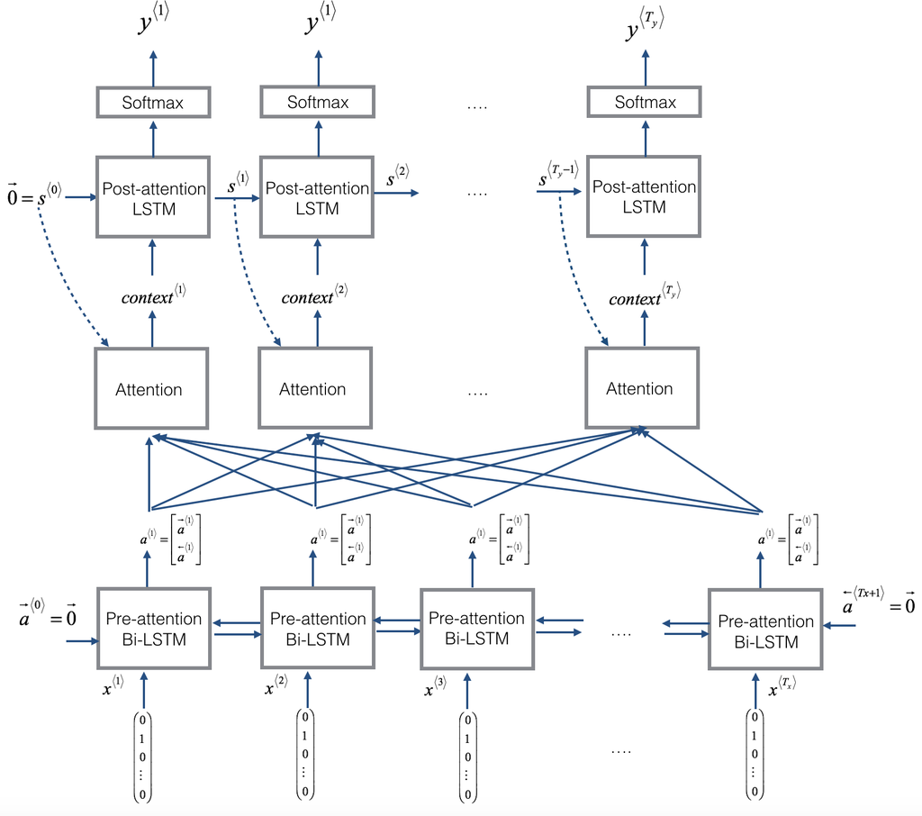

```python
Image("images/attn_model.png", width=600, height=500)
```

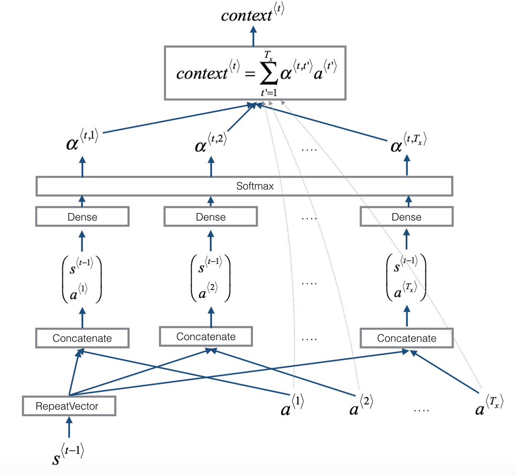

```python
Image("images/attn_mechanism.png", width=600, height=650)
```

Here are some properties of the model that you may notice:

- There are two separate LSTMs in this model (see diagram on the left). Because the one at the bottom of the picture is a Bi-directional LSTM and comes *before* the attention mechanism, we will call it *pre-attention* Bi-LSTM. The LSTM at the top of the diagram comes *after* the attention mechanism, so we will call it the *post-attention* LSTM. The pre-attention Bi-LSTM goes through $T_x$ time steps; the post-attention LSTM goes through $T_y$ time steps.
- The post-attention LSTM passes $s^{\langle t \rangle}, c^{\langle t \rangle}$ from one time step to the next. In the lessons, we were using only a basic RNN for the post-activation sequence model, so the state captured by the RNN output activations $s^{\langle t\rangle}$. But since we are using an LSTM here, the LSTM has both the output activation $s^{\langle t\rangle}$ and the hidden cell state $c^{\langle t\rangle}$. However, unlike previous text generation examples, in this model the post-activation LSTM at time $t$ does will not take the specific generated $y^{\langle t-1 \rangle}$ as input; it only takes $s^{\langle t\rangle}$ and $c^{\langle t\rangle}$ as input. We have designed the model this way, because (unlike language generation where adjacent characters are highly correlated) there isn't as strong a dependency between the previous character and the next character in a YYYY-MM-DD date.
- We use $a^{\langle t \rangle} = [\overrightarrow{a}^{\langle t \rangle}; \overleftarrow{a}^{\langle t \rangle}]$ to represent the concatenation of the activations of both the forward-direction and backward-directions of the pre-attention Bi-LSTM.
- The bottom diagram uses a `RepeatVector` node to copy $s^{\langle t-1 \rangle}$'s value $T_x$ times, and then `Concatenation` to concatenate $s^{\langle t-1 \rangle}$ and $a^{\langle t \rangle}$ to compute $e^{\langle t, t'}$, which is then passed through a softmax to compute $\alpha^{\langle t, t' \rangle}$.

Lets implement this model. You will start by implementing two functions: `one_step_attention()` and `model()`.

- `one_step_attention()`: At step $t$, given all the hidden states of the Bi-LSTM ($[a^{<1>},a^{<2>}, ..., a^{<T_x>}]$) and the previous hidden state of the second LSTM ($s^{<t-1>}$), `one_step_attention()` will compute the attention weights ($[\alpha^{<t,1>},\alpha^{<t,2>}, ..., \alpha^{<t,T_x>}]$) and output the context vector $$context^{<t>} = \sum_{t' = 0}^{T_x} \alpha^{<t,t'>}a^{<t'>}$$

Note that we are denoting the attention in this notebook $context^{\langle t \rangle}$. In the lessons, the context was denoted $c^{\langle t \rangle}$, but here we are calling it $context^{\langle t \rangle}$ to avoid confusion with the (post-attention) LSTM's internal memory cell variable, which is sometimes also denoted $c^{\langle t \rangle}$.

- `model()`: Implements the entire model. It first runs the input through a Bi-LSTM to get back $[a^{<1>},a^{<2>}, ..., a^{<T_x>}]$. Then, it calls `one_step_attention()` $T_y$ times (`for` loop). At each iteration of this loop, it gives the computed context vector $c^{<t>}$ to the second LSTM, and runs the output of the LSTM through a dense layer with softmax activation to generate a prediction $\hat{y}^{<t>}$.

**Exercise**: Implement `one_step_attention()`. The function `model()` will call the layers in `one_step_attention()` $T_y$ using a for-loop, and it is important that all $T_y$ copies have the same weights. I.e., it should not re-initiaiize the weights every time. In other words, all $T_y$ steps should have shared weights. Here's how you can implement layers with shareable weights in Keras:

1. Define the layer objects (as global variables for examples).
2. Call these objects when propagating the input.

```python
# Defined shared layers as global variables
repeator = RepeatVector(Tx)         # Repeats the input Tx times.
concatenator = Concatenate(axis=-1) # Layer that concatenates a list of inputs.
                                    # axis: Axis along which to concatenate, in this case: last axis.
densor1 = Dense(10, activation = "tanh")
# Dense implements the operation: output = activation(dot(input, kernel) + bias)
# where kernel is a weights matrix created by the layer

densor2 = Dense(1, activation = "relu")
activator = Activation(softmax, name='attention_weights')
# We are using a custom softmax(axis = 1)

# Layer that computes a dot product between samples in two tensors.
dotor = Dot(axes = 1)
```

Now you can use these layers to implement `one_step_attention()`. In order to propagate a Keras tensor object X through one of these layers, use `layer(X)` (or `layer([X,Y])` if it requires multiple inputs.), e.g. `densor(X)` will propagate X through the `Dense(1)` layer defined.

```python
def one_step_attention(a, s_prev):
    """
    Performs one step of attention: Outputs a context vector computed as a dot product of the attention weights
    "alphas" and the hidden states "a" of the Bi-LSTM.

    Arguments:
    a -- hidden state output of the Bi-LSTM, numpy-array of shape (m, Tx, 2*n_a)
    s_prev -- previous hidden state of the (post-attention) LSTM, numpy-array of shape (m, n_s)

    Returns:
    context -- context vector, input of the next (post-attetion) LSTM cell
    """

    # Use repeator to repeat s_prev to be of shape (m, Tx, n_s) so that you can concatenate
    # it with all hidden states "a" (≈ 1 line)
    s_prev = repeator(s_prev)

    # Use concatenator to concatenate a and s_prev on the last axis
    concat = concatenator([a,s_prev])

    # Use densor1 to propagate concat through a small fully-connected neural network to
    # compute the "intermediate energies" variable e.
    e = densor1(concat)

    # Use densor2 to propagate e through a small fully-connected neural network to compute
    # the "energies" variable energies
    energies = densor2(e)

    # Use "activator" on "energies" to compute the attention weights "alphas"
    alphas = activator(energies)

    # Use dotor together with "alphas" and "a" to compute the context vector to be given to
    # the next (post-attention) LSTM-cell (≈ 1 line)
    context = dotor([alphas,a])
    return context
```

**Exercise**: Implement `model()`

```python
n_a = 32
n_s = 64
post_activation_LSTM_cell = LSTM(n_s, return_state = True)
output_layer = Dense(len(machine_vocab), activation=softmax)
```

Now you can use these layers $T_y$ times in a `for` loop to generate the outputs, and their parameters will not be reinitialized. You will have to carry out the following steps:

1. Propagate the input into a [Bidirectional](https://keras.io/layers/wrappers/#bidirectional) [LSTM](https://keras.io/layers/recurrent/#lstm)
2. Iterate for $t = 0, \dots, T_y-1$:
   1. Call `one_step_attention()` on $[\alpha^{<t,1>},\alpha^{<t,2>}, ..., \alpha^{<t,T_x>}]$ and $s^{<t-1>}$ to get the context vector $context^{<t>}$.
   2. Give $context^{<t>}$ to the post-attention LSTM cell. Remember pass in the previous hidden-state $s^{\langle t-1\rangle}$ and cell-states $c^{\langle t-1\rangle}$ of this LSTM using `initial_state= [previous hidden state, previous cell state]`. Get back the new hidden state $s^{<t>}$ and the new cell state $c^{<t>}$.
   3. Apply a softmax layer to $s^{<t>}$, get the output.
   4. Save the output by adding it to the list of outputs.
3. Create your Keras model instance, it should have three inputs ("inputs", $s^{<0>}$ and $c^{<0>}$) and output the list of `outputs`.

```python
def model(Tx, Ty, n_a, n_s, human_vocab_size, machine_vocab_size):
    """
    Arguments:
    Tx -- length of the input sequence
    Ty -- length of the output sequence
    n_a -- hidden state size of the Bi-LSTM
    n_s -- hidden state size of the post-attention LSTM
    human_vocab_size   -- size of the python dictionary "human_vocab"
    machine_vocab_size -- size of the python dictionary "machine_vocab"

    Returns:
    model -- Keras model instance
    """

    # Define the inputs of your model with a shape (Tx,)
    # Define s0 and c0, initial hidden state for the decoder LSTM of shape (n_s,)
    X = Input(shape=(Tx, human_vocab_size))
    s0 = Input(shape=(n_s,), name='s0')
    c0 = Input(shape=(n_s,), name='c0')
    s = s0
    c = c0

    # Initialize empty list of outputs
    outputs = []

    # Step 1: Define your pre-attention Bi-LSTM. Remember to use return_sequences=True.
    a = Bidirectional(LSTM(n_a, return_sequences=True))(X)

    # Step 2: Iterate for Ty steps
    for t in range(Ty):

        # Step 2.A: Perform one step of the attention mechanism to get back the context vector at step t
        context = one_step_attention(a, s)

        # Step 2.B: Apply the post-attention LSTM cell to the "context" vector.
        # Don't forget to pass: initial_state = [hidden state, cell state]
        s, _, c = post_activation_LSTM_cell(context,initial_state=[s, c])

        # Step 2.C: Apply Dense layer to the hidden state output of the post-attention LSTM
        out = output_layer(s)

        # Step 2.D: Append "out" to the "outputs" list
        outputs.append(out)

    # Step 3: Create model instance taking three inputs and returning the list of outputs.
    model = Model(inputs=[X, s0, c0], outputs=outputs)
    return model
```

```python
model = model(Tx, Ty, n_a, n_s, len(human_vocab), len(machine_vocab))
```

```python
model.summary()
```

```
__________________________________________________________________________________________________
Layer (type)                    Output Shape         Param #     Connected to
==================================================================================================
input_2 (InputLayer)            (None, 30, 37)       0
__________________________________________________________________________________________________
s0 (InputLayer)                 (None, 64)           0
__________________________________________________________________________________________________
bidirectional_2 (Bidirectional) (None, 30, 64)       17920       input_2[0][0]
__________________________________________________________________________________________________
repeat_vector_2 (RepeatVector)  (None, 30, 64)       0           s0[0][0]
                                                                 lstm_3[0][0]
                                                                 lstm_3[1][0]
                                                                 lstm_3[2][0]
                                                                 lstm_3[3][0]
                                                                 lstm_3[4][0]
                                                                 lstm_3[5][0]
                                                                 lstm_3[6][0]
                                                                 lstm_3[7][0]
                                                                 lstm_3[8][0]
__________________________________________________________________________________________________
concatenate_2 (Concatenate)     (None, 30, 128)      0           bidirectional_2[0][0]
                                                                 repeat_vector_2[0][0]
                                                                 bidirectional_2[0][0]
                                                                 repeat_vector_2[1][0]
                                                                 bidirectional_2[0][0]
                                                                 repeat_vector_2[2][0]
                                                                 bidirectional_2[0][0]
                                                                 repeat_vector_2[3][0]
                                                                 bidirectional_2[0][0]
                                                                 repeat_vector_2[4][0]
                                                                 bidirectional_2[0][0]
                                                                 repeat_vector_2[5][0]
                                                                 bidirectional_2[0][0]
                                                                 repeat_vector_2[6][0]
                                                                 bidirectional_2[0][0]
                                                                 repeat_vector_2[7][0]
                                                                 bidirectional_2[0][0]
                                                                 repeat_vector_2[8][0]
                                                                 bidirectional_2[0][0]
                                                                 repeat_vector_2[9][0]
```

[output cut: 88 more lines]

```
dense_6 (Dense)                 (None, 11)           715         lstm_3[0][0]
                                                                 lstm_3[1][0]
                                                                 lstm_3[2][0]
                                                                 lstm_3[3][0]
                                                                 lstm_3[4][0]
                                                                 lstm_3[5][0]
                                                                 lstm_3[6][0]
                                                                 lstm_3[7][0]
                                                                 lstm_3[8][0]
                                                                 lstm_3[9][0]
==================================================================================================
Total params: 52,960
Trainable params: 52,960
Non-trainable params: 0
__________________________________________________________________________________________________
```

Compile your model using `categorical_crossentropy` loss, a custom ADAM ($\alpha=0.005$, $\beta_1 = 0.9$, $\beta_2 = 0.999$, $\gamma = 0.01$) with `['accuracy']` metrics

```python
opt = Adam(lr=0.005, beta_1=0.9, beta_2=0.999, decay=0.01)
model.compile(optimizer=opt, loss='categorical_crossentropy', metrics=['accuracy'])
```

The last step is to define all your inputs and outputs:

```python
s0 = np.zeros((m, n_s))
c0 = np.zeros((m, n_s))
outputs = list(Yoh.swapaxes(0,1))
```

```python
model.fit([Xoh, s0, c0], outputs, epochs=1, batch_size=100)
```

```
<keras.callbacks.History at 0x7ff3aecddcc0>
```

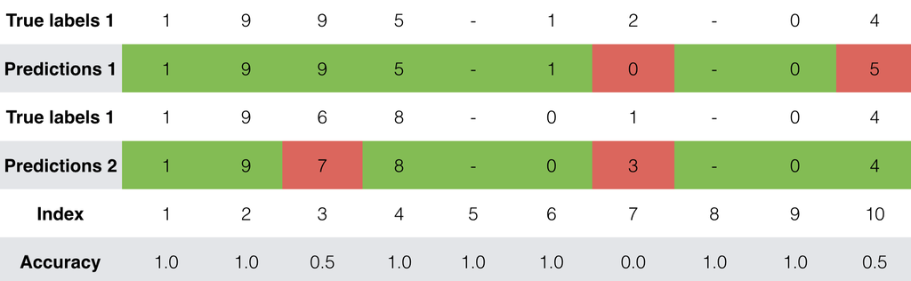

```python
Image("images/table.png", width=800)
```

While training you can see the loss as well as the accuracy on each of the 10 positions of the output. The table above gives an example of what the accuracies could be if the batch had 2 examples. `dense_8_acc_8: 0.9` means that you are predicting the 7th character of the output correctly 90% of the time in the current batch of data. We have run this model for longer, and saved the weights.

```python
model.load_weights('models/model.h5')
```

Example:

```
source: 3 May 1979
output: 1979-05-03
source: 5 April 09
output: 2009-05-05
source: 21th of August 2016
output: 2016-08-21
source: Tue 10 Jul 2007
output: 2007-07-10
source: Saturday May 9 2018
output: 2018-05-09
source: March 3 2001
output: 2001-03-03
```

## Visualizing Attention

Since the problem has a fixed output length of 10, it is also possible to carry out this task using 10 different softmax units to generate the 10 characters of the output. But one advantage of the attention model is that each part of the output (say the month) knows it needs to depend only on a small part of the input (the characters in the input giving the month). We can visualize what part of the output is looking at what part of the input.

Consider the task of translating "Saturday 9 May 2018" to "2018-05-09". If we visualize the computed $\alpha^{\langle t, t' \rangle}$ we get this:

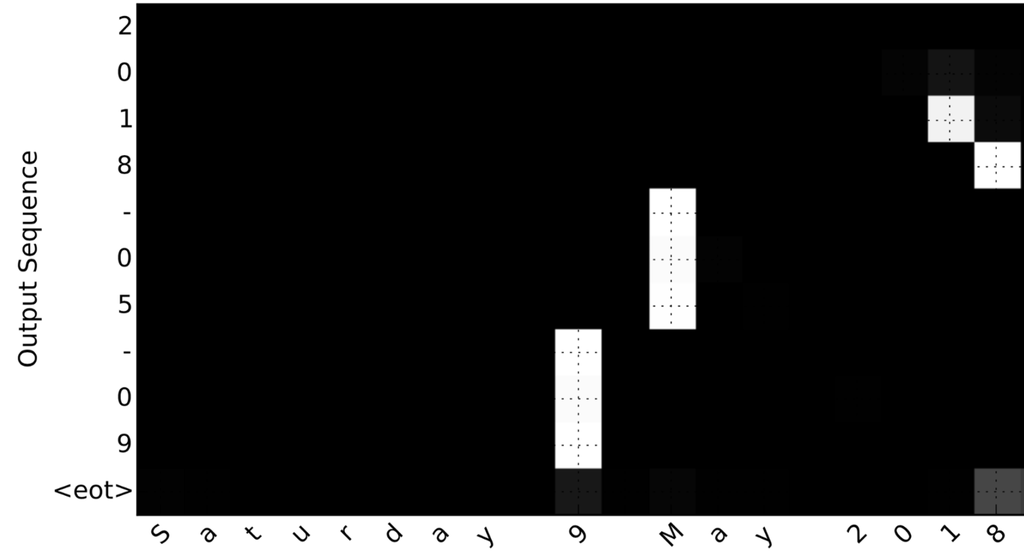

```python
Image("images/date_attention.png", width=800)
```

Notice how the output ignores the Saturday portion of the input. None of the output timesteps are paying much attention to that portion of the input. We see also that 9 has been translated as 09 and May has been correctly translated into 05, with the output paying attention to the parts of the input it needs to to make the translation. The year mostly requires it to pay attention to the input's 18 in order to generate 2018

### Getting the activations from the network

Lets now visualize the attention values in your network. We'll propagate an example through the network, then visualize the values of $\alpha^{\langle t, t' \rangle}$. To figure out where the attention values are located, let's start by printing a summary of the model .

```python
model.summary()
```

```
__________________________________________________________________________________________________
Layer (type)                    Output Shape         Param #     Connected to
==================================================================================================
input_2 (InputLayer)            (None, 30, 37)       0
__________________________________________________________________________________________________
s0 (InputLayer)                 (None, 64)           0
__________________________________________________________________________________________________
bidirectional_2 (Bidirectional) (None, 30, 64)       17920       input_2[0][0]
__________________________________________________________________________________________________
repeat_vector_2 (RepeatVector)  (None, 30, 64)       0           s0[0][0]
                                                                 lstm_3[0][0]
                                                                 lstm_3[1][0]
                                                                 lstm_3[2][0]
                                                                 lstm_3[3][0]
                                                                 lstm_3[4][0]
                                                                 lstm_3[5][0]
                                                                 lstm_3[6][0]
                                                                 lstm_3[7][0]
                                                                 lstm_3[8][0]
__________________________________________________________________________________________________
concatenate_2 (Concatenate)     (None, 30, 128)      0           bidirectional_2[0][0]
                                                                 repeat_vector_2[0][0]
                                                                 bidirectional_2[0][0]
                                                                 repeat_vector_2[1][0]
                                                                 bidirectional_2[0][0]
                                                                 repeat_vector_2[2][0]
                                                                 bidirectional_2[0][0]
                                                                 repeat_vector_2[3][0]
                                                                 bidirectional_2[0][0]
                                                                 repeat_vector_2[4][0]
                                                                 bidirectional_2[0][0]
                                                                 repeat_vector_2[5][0]
                                                                 bidirectional_2[0][0]
                                                                 repeat_vector_2[6][0]
                                                                 bidirectional_2[0][0]
                                                                 repeat_vector_2[7][0]
                                                                 bidirectional_2[0][0]
                                                                 repeat_vector_2[8][0]
                                                                 bidirectional_2[0][0]
                                                                 repeat_vector_2[9][0]
```

[output cut: 88 more lines]

```
dense_6 (Dense)                 (None, 11)           715         lstm_3[0][0]
                                                                 lstm_3[1][0]
                                                                 lstm_3[2][0]
                                                                 lstm_3[3][0]
                                                                 lstm_3[4][0]
                                                                 lstm_3[5][0]
                                                                 lstm_3[6][0]
                                                                 lstm_3[7][0]
                                                                 lstm_3[8][0]
                                                                 lstm_3[9][0]
==================================================================================================
Total params: 52,960
Trainable params: 52,960
Non-trainable params: 0
__________________________________________________________________________________________________
```

Navigate through the output of `model.summary()` above. You can see that the layer named `attention_weights` outputs the `alphas` of shape (m, 30, 1) before `dot_2` computes the context vector for every time step $t = 0, \ldots, T_y-1$. Lets get the activations from this layer.

The function `attention_map()` pulls out the attention values from your model and plots them.

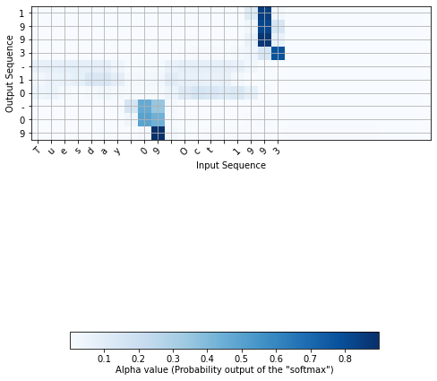

```python
attention_map = plot_attention_map(model, human_vocab, inv_machine_vocab, "Tuesday 09 Oct 1993", num = 7, n_s = 64)
```